# K-means

## Подгрузка пакетов

```r
library(tibble)
library(readr)
library(dplyr)
library(ggplot2)
```

## Алгоритм

Алгоритм нахождения кластеров:

1. Выбор количества кластеров. Вы должны изначально знать сколько кластеров должно получиться. Это и есть $k$.
2. Случайным образом инициализируются $k$ точек. Эти точки будут центроидами кластеров.
3. Каждое наблюдение присваивается к кластеру, к которому оно ближе всего.
4. Центроиды пересчитываются, их координаты равны средним значениям наблюдений, которые были получены на предыдущем этапе.
5. Пункты 3 и 4 повторяются до тех пор пока центроиды не стабилизируются, то есть наблюдения не будут перетекать из одного кластера в другой.

Давайте посмотрим как работает кластеризация на очень простом примере.

```r
source_df <- read_csv("simple_sample.csv")
source_df %>%
  head()
```

```
## # A tibble: 6 x 2
##       x1     x2
##    <dbl>  <dbl>
## 1 -9.21   0.205
## 2 -0.384 -0.137
## 3  0.464 -1.61
## 4 -7.61   2.73
## 5 -8.42   2.25
## 6 -6.80   1.85
```

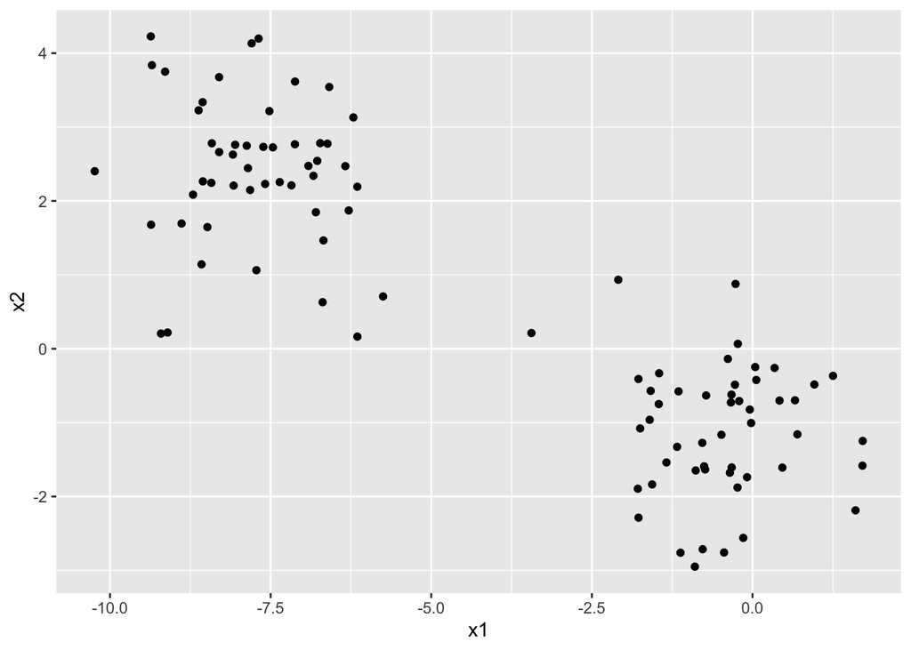

```r
ggplot(source_df, aes(x1, x2)) +
  geom_point()
```

Видно, что здесь есть 2 кластера. Давай попробуем построить модель.

```r
model <- kmeans(source_df, centers = 2)
df <- source_df %>%
  mutate(cluster = factor(model$cluster))
df %>%
  head()
```

```
## # A tibble: 6 x 3
##       x1     x2 cluster
##    <dbl>  <dbl> <fct>
## 1 -9.21   0.205 2
## 2 -0.384 -0.137 1
## 3  0.464 -1.61  1
## 4 -7.61   2.73  2
## 5 -8.42   2.25  2
## 6 -6.80   1.85  2
```

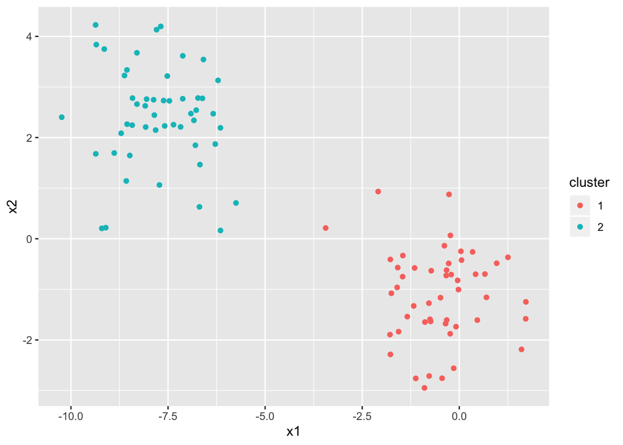

```r
ggplot(df, aes(x1, x2, color=cluster)) +
  geom_point()
```

## Выбор k

Посмотрев на график из предыдущего примера мы сразу поняли, что у нас есть 2 кластера. Это было легко, так как мы смотрели на график в двумерном пространстве. На график в трехмерном пространстве мы тоже можем посмотреть. Но как понять сколько кластеров, если количество переменных в нашем датасете больше 3?

### Elbow method (метод согнутого плеча)

Чтобы понять как работает этот метод, давайте сначала определим **total within-cluster sum of squares**. Это метрика, которая показывает насколько далеко находятся наблюдения от центроидов своего кластера.

$$TotalWithinSS = \sum_{i=1}^k\sum_{x \in C_i}d(x, \bar x_{C_i})^2$$

Первая сумма отвечает за каждый кластер ($i$). Вторая сумма перебирает все точки $x$, которые находятся в $i$ кластере. В итоге суммируется расстояние от точки до центроида ее кластера и возводится в квадрат. В построенной моделе уже есть эта метрика.

```r
print(model$withinss)  # значение для каждого кластера
## [1]  90.86976 102.79108
print(model$tot.withinss)  # суммарное значение
## [1] 193.6608
```

Давайте напишем функцию, которая построит нам график на котором будет визуально видна суть этой метрики.

```r
PlotWithinSS <- function(df, k){
  model <- kmeans(df, centers = k)

  df <- df %>%
    mutate(cluster = model$cluster)
  centers <- model$centers
  centers <- as_tibble(centers) %>%
    setNames(paste0('center.', names(.))) %>%
    mutate(cluster = row_number())
  segment_df <- df %>%
    inner_join(centers, by = 'cluster')
  p <- ggplot(df, aes(x1, x2, color=factor(cluster))) +
    geom_point() +
    geom_point(aes(center.x1, center.x2), data = centers, color = 'black', size = 2) +
    geom_segment(aes(x = x1, y = x2, xend = center.x1, yend = center.x2),
                 data = segment_df, color = 'black', linetype = 2, size = 0.3, alpha = 0.5) +
    theme(legend.position="none") +
    labs(subtitle = paste("TotalWithinSS = ", round(model$tot.withinss)))
  return(p)
}
```

Например, построим график с 2 кластерами. Пунктирные линии от центра кластера (черной точки) до всех других точек кластера показывают расстояние. Сумма квадратов этих расстояний и есть наша метрика **TotalWithinSS**.

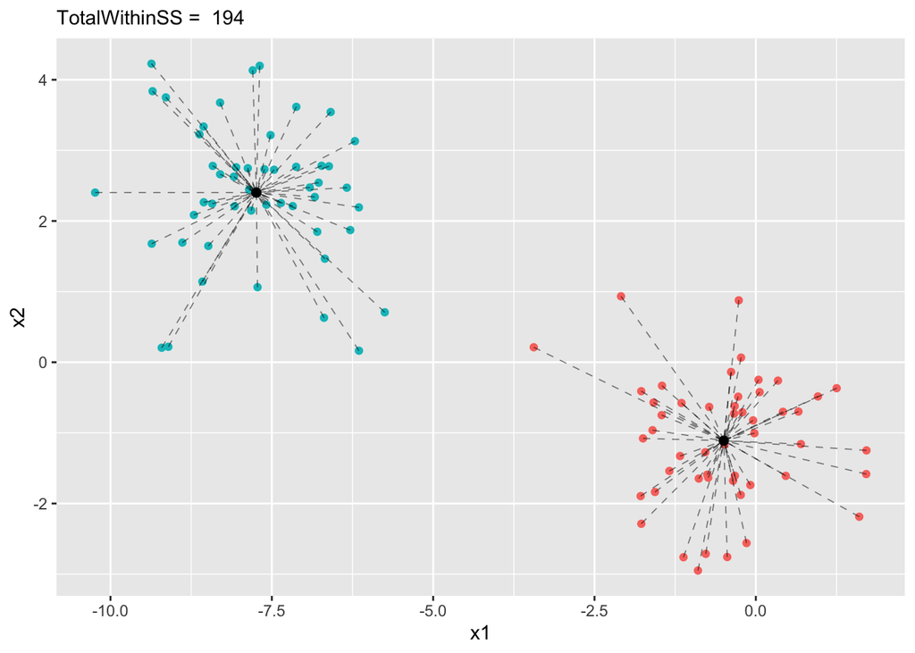

```r
PlotWithinSS(df, 2)
```

Само значение этой метрики ничего нам не дает. Но это значение можно сравнивать с другими значениями. Давайте построим несколько графиков с разным количеством кластеров.

Чтобы построить графики рядом друг с другом воспользуемся пакетом `ggpubr`, в котором находится функция `ggarange`

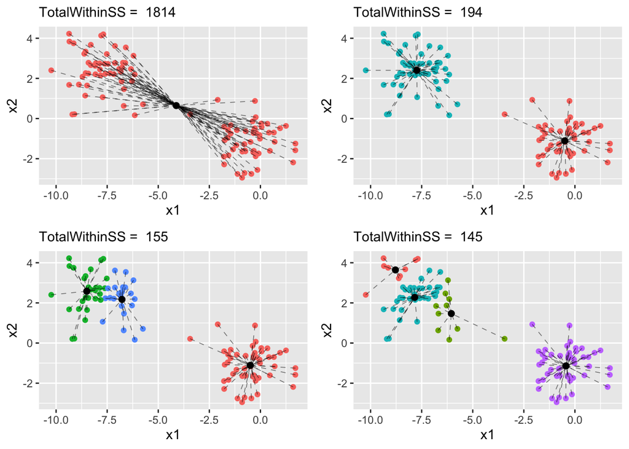

```r
library(ggpubr)

p1 <- PlotWithinSS(source_df, 1)
p2 <- PlotWithinSS(source_df, 2)
p3 <- PlotWithinSS(source_df, 3)
p4 <- PlotWithinSS(source_df, 4)

ggarrange(p1, p2, p3, p4, nrow = 2, ncol = 2)
```

Видно, что когда кластер 1, то метрика очень большая, так как дистанция между центров кластера и всеми точками очень велико. Важно заметить, что изменение метрики при переходе от 1 кластера ко 2 велико по сравнению с изменением при переходе от 2 к 3 или от 3 к 4. Давайте построим 10 моделей и изобразим эту динамику на графике.

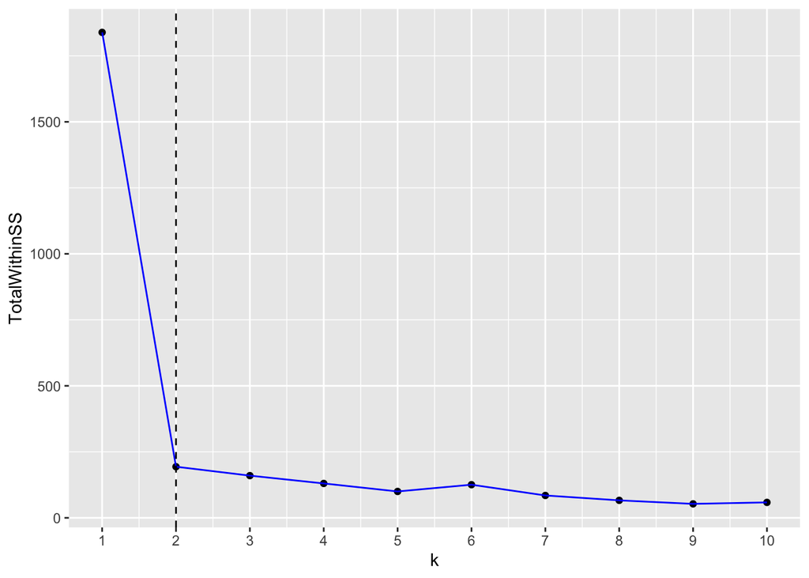

```r
K <- 1:10
TotalWithinSS <- c()
for(k in K){
  model <- kmeans(df, centers = k)
  TotalWithinSS <- c(TotalWithinSS, model$tot.withinss)
}
metrics_df <- tibble(k = K, TotalWithinSS = TotalWithinSS)

ggplot(metrics_df, aes(k, TotalWithinSS)) +
  geom_point() +
  geom_line(color = 'blue') +
  scale_x_continuous(breaks = K) +
  geom_vline(xintercept = 2, linetype = 2)
```

На этом графике прекрасно видно, что кластеров должно быть 2, так как при увеличении количества кластеров значение метрики не так сильно падает. Это в свою очередь означает, что добавление новых кластеров избыточно.

Этот график достаточно прост. Изменение метрики при переходе от 2 до 3 кластеров может быть больше. Здесь уже вам нужно выбирать некоторый порог, который будет сигнализировать достаточно ли этого изменени, чтобы увеличить количество кластеров.

### Silhouette method (метод “силуэта”)

Другим способом определения количества кластеров является *Silhouette method*. Этот метод предполагает расчет так называемой ширины “силуэта”. Это метрика расчитывается для каждого наблюдения и состоит из двух частей:

1. **Within Cluster Distance** – расстояние внутри кластера. Для $i$-ого наблюдения $C(i)$.
2. **Closest Neighbor Distance** – расстояние до ближайшего соседнего кластера. Для $i$-ого наблюдения $N(i)$.

Предположим мы решили выбрать 3 кластера. Давайте посмотрим на отдельном наблюдении на каждую составляющую метрики.

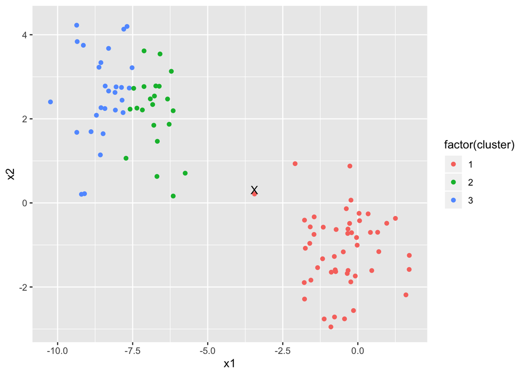

```r
set.seed(42)
model <- kmeans(source_df, centers = 3)
df <- source_df %>%
  mutate(cluster = model$cluster) %>%
  mutate(label = if_else(x1 < -2.5 & x1 > -5., "X", ""))

p <- ggplot(df, aes(x1, x2, color=factor(cluster), label = label)) +
  geom_point() +
  geom_text(nudge_y = 0.1, show.legend = F, color = "black")
p
```

Для этого наблюдения **Within Cluster Distance** равна средней дистанции до каждой точки из 1 кластера.

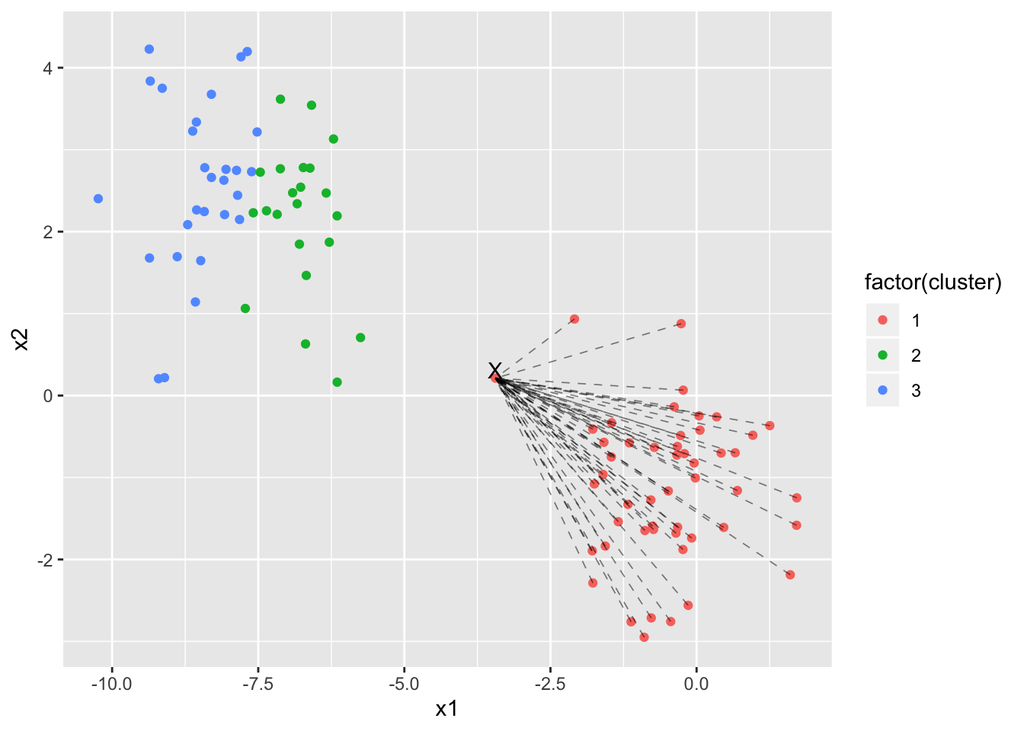

```r
segment_df <- df %>%
  filter(label == "X") %>%
  setNames(paste0('X.', names(.))) %>%
  full_join(df, by = character())

p + geom_segment(aes(x = x1, y = x2, xend = X.x1, yend = X.x2),
               data = segment_df %>% filter(cluster == 1),
               color = 'black', linetype = 2, size = 0.3, alpha = 0.5)
```

```r
segment_df %>%
  filter(cluster == 1) %>%
  mutate(distance = sqrt((X.x1 - x1)**2 + (X.x2 - x2)**2)) %>%
  summarise(C = mean(distance))
```

```
## # A tibble: 1 x 1
##       C
##   <dbl>
## 1  3.35
```

Видно, что ближайший к нашему наблюдению является второй кластер. Поэтому для этого наблюдения **Closest Neighbor Distance** равна средней дистанции до каждой точки из 2 кластера.

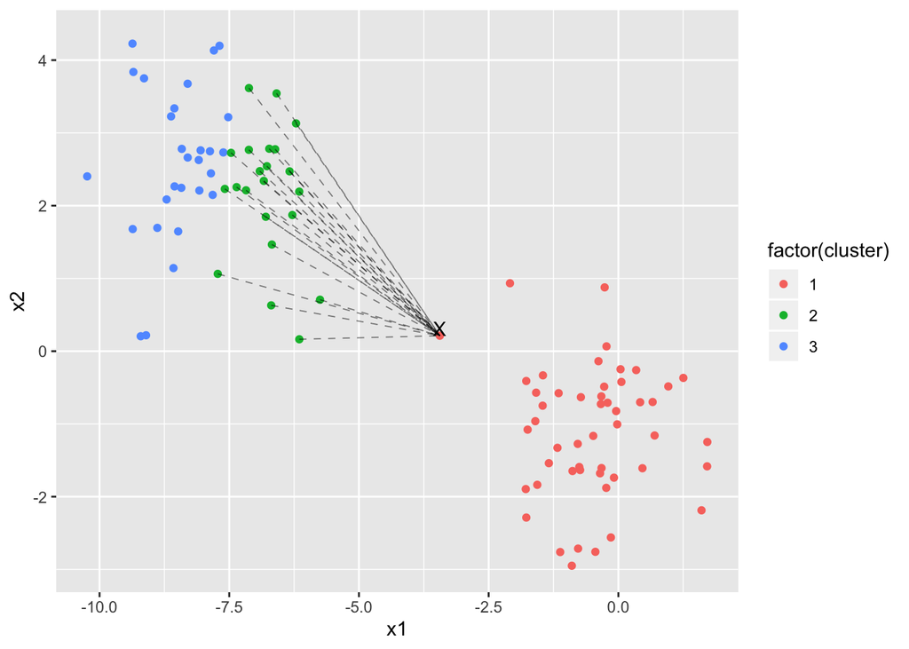

```r
p + geom_segment(aes(x = x1, y = x2, xend = X.x1, yend = X.x2),
               data = segment_df %>% filter(cluster == 2),
               color = 'black', linetype = 2, size = 0.3, alpha = 0.5)
```

```r
segment_df %>%
  filter(cluster == 2) %>%
  mutate(distance = sqrt((X.x1 - x1)**2 + (X.x2 - x2)**2)) %>%
  summarise(N = mean(distance))
```

```
## # A tibble: 1 x 1
##       N
##   <dbl>
## 1  3.95
```

Используя 2 эти состовляющие мы можем посчитать ширину “силуэта”.

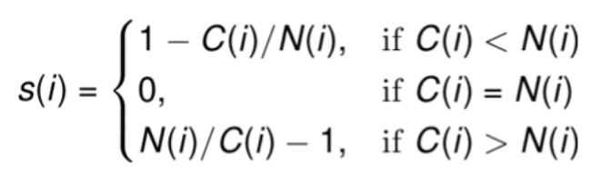

В нашем случае она равна:

```r
round(1 - 3.35 / 3.95, 2)
```

```
## [1] 0.15
```

Данная метрика может принимать значения от -1 до 1.

- Значение близкое к 1 предполагает, что это наблюдение хорошо “вписывается” в текущий кластер.
- Значение близкое к 0 предполагает, что это наблюдение находится на границе между двумя кластерами и может принадлежать одному из них.
- Значение близкое к -1 предполагает, что это наблюдение лучше подходит другому кластеру.

В нашем случае наблюдение больше подходит к своему кластеру, хотя достаточно близко и к соседнему. Если взять точку между 2 и 3 кластерами, то там могут получиться и отрицательные значения метрики.

Сейчас мы посчитали эту метрику только для одного наблюдения. Чтобы понять ситуацию в целом, нужно посчитать эту метрику для каждого наблюдения и усреднить. Для этого нам поможет пакет `cluster`.

```r
library(cluster)

set.seed(42)
pam3 <- pam(source_df, k = 3)
```

Из объекта мы можем получить значение метрики.

```r
pam3$silinfo$widths %>%
  head()
```

```
##    cluster neighbor sil_width
## 55       1        3 0.4475706
## 86       1        3 0.4334942
## 82       1        3 0.4298834
## 31       1        3 0.4281010
## 37       1        3 0.4274173
## 34       1        3 0.4257712
```

```r
pam3$silinfo$avg.width
```

```
## [1] 0.5453131
```

Можно нарисовать график.

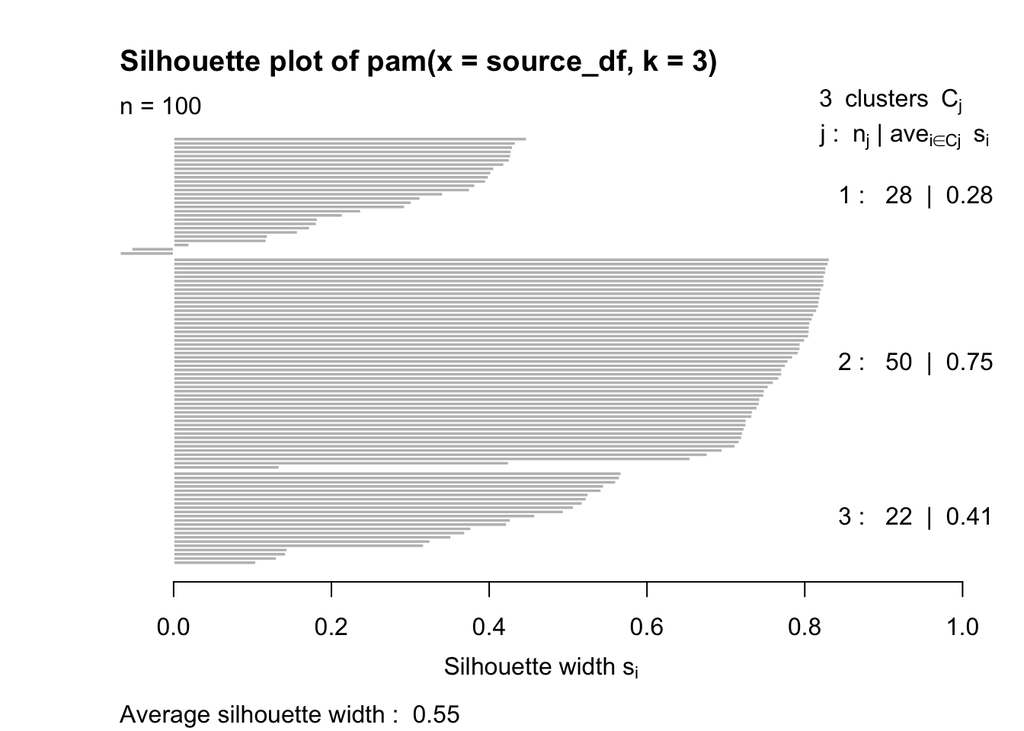

```r
plot(silhouette(pam3))
```

Теперь можно построить разные модели и понять для какой эта метрика наилучшая.

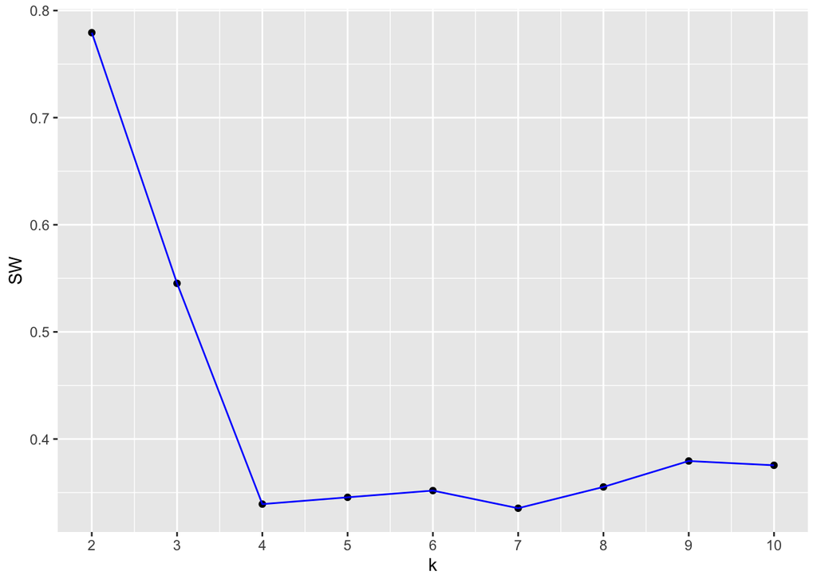

```r
K <- 2:10
SW <- c()
for(k in K){
  model <- pam(source_df, k = k)
  SW <- c(SW, model$silinfo$avg.width)
}
metrics_df <- tibble(k = K, SW = SW)

ggplot(metrics_df, aes(k, SW)) +
  geom_point() +
  geom_line(color = 'blue') +
  scale_x_continuous(breaks = K)
```

И по этой метрике мы видим, что 2 кластера это оптимальный вариант, так как именно модель с 2 кластерами имеет наивысшее значение.